# Assignment 6

Import the "pandas" and "matplotlib.pyplot" libraries (and any other libraries if you would like)

```python
# Import libraries
import pandas as pd
import matplotlib.pyplot as plt
```

(a) Functions

- Read in the dataset named "features.csv".
- Create a `lambda` function that checks if weight $≤$ 3000
- Using the Pandas method `.apply()`, create a new Series that shows `True` if weight $≤$ 3000 and `False`if weight > 3000.
- Using the `.shape` attribute, print the number of cars that have weight $≤$ 3000.

**Hint**: A Pandas Series has only one dimension, so the `.shape` attribute is a "tuple" with only one element. In order to get a single integer, type `your_variable_name.shape[0]`

```python
# Write your answer here:
features = pd.read_csv("data/features.csv")

check_weight = lambda x: x <= 3000

car_weight_light = features['weight'].apply(check_weight)

num_car_light= car_weight_light[car_weight_light == True].shape[0]

print("The number of cars that have weight <= 3000 is:", num_car_light)
```

```
The number of cars that have weight <= 3000 is: 230
```

(b) Subsetting Data

- Read in the dataset named "features.csv".
- Define a global variable called `threshold` that takes the  
  value 2500
- Subset the data to get one dataset with weight $>$ threshold and  
  another with weight $\le$ threshold. Use the `.query()` function.
- Compute the mean acceleration for each of these datasets, printing these values to the screen

Note: Review how to define a global variable inside `.query()`

```python
# Write your answer here:
features = pd.read_csv("data/features.csv")

threshold = 2500

heavier_car = features.query("weight > @threshold")
lighter_car = features.query("weight <= @threshold")

mean_acceleration_heavier = heavier_car["acceleration"].mean()
mean_acceleration_lighter = lighter_car["acceleration"].mean()

print("The mean acceleration for heavier cars is:", mean_acceleration_heavier)
print("The mean acceleration for lighter cars is:", mean_acceleration_lighter)
```

```
The mean acceleration for heavier cars is: 14.999601593625497
The mean acceleration for lighter cars is: 16.53877551020408
```

(c) Use sorting + ".iloc[]"

- Read the "fifa23_players_basic.csv" dataset
- Use ".sort_values()" to order the "Age" column  
  from oldest to youngest
- Get a subset with the 5 oldest players

```python
# Write your answer here:
fifa23_players = pd.read_csv("data/fifa23_players_basic.csv")
sort_age = fifa23_players.sort_values(by="Age", ascending = False)
oldest_players = sort_age.iloc[:5, :]
```

(d) Use queries + global variables

- Read the "fifa23_players_basic.csv" dataset
- Compute the mean of the column "Weight(in kg)" and store it as a variable
- Subset the players whose Weight in kilograms is stricly large than this mean value using ".query()"

HINT: Remember that there is a special syntax for when using column names inside the .query() method (the backtick `)

```python
# Write your answer here:
fifa23_players = pd.read_csv("data/fifa23_players_basic.csv")

mean_weight = fifa23_players["Weight(in kg)"].mean()
larger_weight_players = fifa23_players.query("`Weight(in kg)` > @mean_weight")
```

(e) Plot by Category

Read in the dataset named "wdi_urban.csv".

This contains data from 1980 and 2020.

- **Create an array with the unique values of "year" using the `Pandas` function `unique`**
- **Create a plot with a ...**
  - Histogram of "prop_urbanpopulation" (proportion of urban population) for each year
  - Set the histogram option `alpha = 0.5` for transparency
  - All the histograms should be overlapping on the same plot
  - Create a legend with the list of years
  - Label the axes and the title

**Hint**: The procedure will be similar (but not exactly the same!) as when we created a scatter plot of cars with different numbers of cylinders in Lecture 11

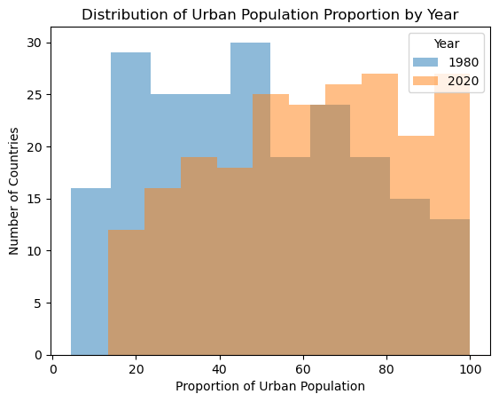

```python
# your answer here
wdi_urban = pd.read_csv("data/wdi_urban.csv")

year = pd.unique(wdi_urban["year"])

plt.figure()

for y in year:
    df = wdi_urban.query("year == @y")
    plt.hist(x = df["prop_urbanpopulation"], alpha = 0.5)

plt.xlabel("Proportion of Urban Population")
plt.ylabel("Number of Countries")
plt.title("Distribution of Urban Population Proportion by Year")
plt.legend(labels = year, title="Year")

plt.show()
```